# Zelig 5 Quickstart Guide

2017-05-03

The release of Zelig 5.0 expands the set of models available, while simplifying the model wrapping process, and solving architectural problems by completely rewriting into R’s Reference Classes for a fully object-oriented architecture. Comparability wrappers are available so that you can still use pre-Zelig 5 syntax.

## Zelig 5 workflow overview

All models in Zelig 5 can be estimated and results explored presented using a five simple steps:

- Initialise the Zelig object, e.g with `z.out <- zls$new()` for a least squares model. Then populate the object with:
- `zelig` to estimate the parameters,
- `setx` to set fitted values for which we want to find quantities of interest,
- `sim` to simulate the quantities of interest,
- `graph` to plot the simulation results.

### Differences from Zelig 4 and backwards compatability

Zelig 5 uses [reference classes](http://adv-r.had.co.nz/R5.html) which work a bit differently from what you may expect in R. The big difference is that they are “mutable”, i.e. assigning values to them does not overwrite the objects previous contents.

Zelig 5 does contain wrappers (largely) allowing you to use Zelig 4 syntax if you’d like. Here is an example workflow with Zelig 5:

```r
z5 <- zls$new()
z5$zelig(Y ~ X1 + X ~ X, weights = w, data = mydata)
z5$setx()
z5$sim()
z5$graph()
```

Here is the same set of operations using the Zelig 4 wrappers:

```r
z.out <- zelig(Y ~ X1 + X2, model = "ls", weights = w, data = mydata)
x.out <- setx(z.out)
s.out <- sim(z.out, x = x.out)
plot(s.out)
```

Note that all of the output objects from the Zelig 4 wrappers are Zelig 5 reference class objects, so you can mix and match which syntax you like.

## Zelig 5 Quickstart Guide

Let’s walk through an example. This example uses the swiss dataset. It contains data on fertility and socioeconomic factors in Switzerland’s 47 French-speaking provinces in 1888 (Mosteller and Tukey, 1977, 549-551). We will model the effect of education on fertility, where education is measured as the percent of draftees with education beyond primary school and fertility is measured using the common standardized fertility measure (see Muehlenbein (2010, 80-81) for details).

## Installing and Loading Zelig

If you haven’t already done so, open your R console and install Zelig:

```r
install.packages('Zelig')
```

Alternatively you can install the development version with:

```r
devtools::install_github('IQSS/Zelig')
```

Once Zelig is installed, load it:

```r
library(Zelig)
```

## Building Models

Let’s assume we want to estimate the effect of education on fertility. Since fertility is a continuous variable, least squares is an appropriate model choice. We first create a Zelig least squares object:

```r
# initialize Zelig5 least squares object
z5 <- zls$new()
```

To estimate our model, we call the `zelig()` method, which is a function that is internal to the Zelig object. We pass the `zelig()` method two arguments: equation and data:

```r
# estimate ls model
z5$zelig(Fertility ~ Education, data = swiss)

# model summary
summary(z5)
```

```
## Model:
##
## Call:
## z5$zelig(formula = Fertility ~ Education, data = swiss)
##
## Residuals:
##     Min      1Q  Median      3Q     Max
## -17.036  -6.711  -1.011   9.526  19.689
##
## Coefficients:
##             Estimate Std. Error t value Pr(>|t|)
## (Intercept)  79.6101     2.1041  37.836  < 2e-16
## Education    -0.8624     0.1448  -5.954 3.66e-07
##
## Residual standard error: 9.446 on 45 degrees of freedom
## Multiple R-squared:  0.4406, Adjusted R-squared:  0.4282
## F-statistic: 35.45 on 1 and 45 DF,  p-value: 3.659e-07
##
## Next step: Use 'setx' method
```

The -0.8624 coefficient on education suggests a negative relationship between the education of a province and its fertility rate. More precisely, for every one percent increase in draftees educated beyond primary school, the fertility rate of the province decreases 0.8624 units. To help us better interpret this finding, we may want other quantities of interest, such as expected values or first differences. Zelig makes this simple by automating the translation of model estimates into interpretable quantities of interest using Monte Carlo simulation methods (see King, Tomz, and Wittenberg (2000) for more information). For example, let’s say we want to examine the effect of increasing the percent of draftees educated from 5 to 15. To do so, we set our predictor value using the `setx()` method:

```r
# set education to 5
z5$setx(Education = 5)

# set education to 15
z5$setx1(Education = 15)

# model summary
summary(z5)
```

```
## setx:
##   (Intercept) Education
## 1           1         5
## setx1:
##   (Intercept) Education
## 1           1        15
##
## Next step: Use 'sim' method
```

After setting our predictor value, we simulate using the `sim()` method:

```r
# run simulations and estimate quantities of interest
z5$sim()

# model summary
summary(z5)
```

```
##
##  sim x :
##  -----
## ev
##       mean       sd      50%     2.5%    97.5%
## 1 75.25056 1.669638 75.28154 71.95249 78.43345
## pv
##          mean       sd      50%     2.5%    97.5%
## [1,] 75.29561 9.930398 75.60807 56.23094 94.95506
##
##  sim x1 :
##  -----
## ev
##       mean       sd      50%     2.5%    97.5%
## 1 66.61588 1.511457 66.56733 63.75964 69.64819
## pv
##          mean       sd      50%     2.5%    97.5%
## [1,] 67.00618 9.298457 67.13893 48.63484 85.41276
## fd
##        mean       sd      50%      2.5%     97.5%
## 1 -8.634681 1.443048 -8.62762 -11.48837 -5.774374
```

At this point, we’ve estimated a model, set the predictor value, and estimated easily interpretable quantities of interest. The `summary()` method shows us our quantities of interest, namely, our expected and predicted values at each level of education, as well as our first differences–the difference in expected values at the set levels of education.

# Visualizations

Zelig’s `graph()` method plots the estimated quantities of interest:

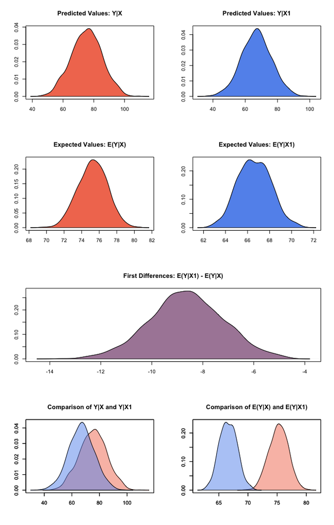

```r
z5$graph()
```

We can also simulate and plot simulations from ranges of simulated values. For example, first use the `setrange` method to set a range of fitted values for one of the covariates and draw simulations as before:

```r
z5 <- zls$new()
z5$zelig(Fertility ~ Education, data = swiss)

# set Education to range from 5 to 15 at single integer increments
z5$setrange(Education = 5:15)

# run simulations and estimate quantities of interest
z5$sim()
```

Then use the `graph()` method as before:

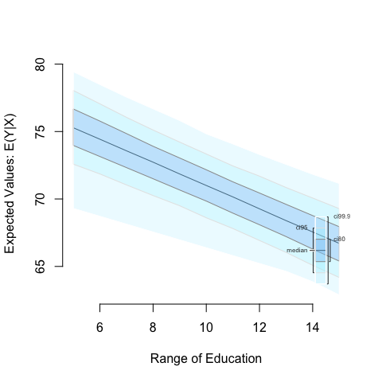

```r
z5$graph()
```